# Data-Driven Marketing: 1st Assignment

Group 3:Azzollini Francesca, Caramelli Leonardo, Mosezon Davide, Stefanelli Riccardo

2022-10-05

# 1 Assignment_1

## 1.1 Description

The database I am sharing with you is from a major European book retailer operating in one country. The retailer uses three sales channels—physical retail stores, catalogs, and the Internet—and uses a subscription business model. Thus, to be eligible to purchase, each customer must become a member. A code is associated with each customer, tracking each time they buy and from which channel. Therefore, we have information on which channel each customer selected on each purchase occasion, the date in which he/she was acquired and when he/she terminated the subscription, how much was spent, and age and gender demographics. Each channel shares the same assortment and price.

I will ask you to explore this dataset. Extract the information it contains and relate it to decision problems.

I expect you to hand in a report on this analysis by Monday 10th, at 24:00.

## 1.2 Analysys

```
## Rows: 4,585
## Columns: 28
## $ h               <dbl> 1, 2, 3, 4, 5, 6, 7, 8, 9, 10, 11, 12, 13, 14, 15, 16,…
## $ revenues_total  <dbl> 679.6, 54.6, 389.9, 146.8, 78.4, 214.5, 397.2, 529.1, …
## $ retention       <dbl> 1, 0, 1, 0, 0, 1, 1, 1, 1, 0, 0, 0, 1, 0, 0, 0, 0, 1, …
## $ yearEND         <dbl> 0, 2006, 0, 2003, 2003, 0, 0, 0, 0, 2003, 2004, 2004, …
## $ bigcity         <dbl> 0, 0, 0, 0, 0, 0, 0, 0, 0, 0, 0, 0, 0, 0, 0, 0, 0, 0, …
## $ mean_city       <dbl> 0, 0, 0, 0, 1, 0, 0, 0, 0, 0, 1, 0, 0, 0, 0, 0, 0, 0, …
## $ nord            <dbl> 0, 0, 0, 0, 1, 0, 0, 0, 0, 0, 1, 0, 0, 0, 0, 0, 0, 0, …
## $ cap2            <dbl> 9047, 50032, 50038, 38100, 16128, 70010, 23868, 37012,…
## $ yearBEGIN       <dbl> 2001, 2001, 2001, 2001, 2001, 2001, 2001, 2001, 2001, …
## $ date_BEGIN      <dttm> 2001-11-12, 2001-07-26, 2001-07-26, 2001-08-20, 2001-…
## $ date_END        <dttm> NA, 2006-06-20, NA, 2003-07-28, NA, NA, NA, NA, NA, 2…
## $ age             <dbl> 32, 40, 50, 25, 89, 29, 29, 33, 42, 48, 42, 36, 44, 41…
## $ vpccdpro        <chr> "CA", "FI", "FI", "VR", "GE", "BA", "LC", "VR", "VR", …
## $ age_missing     <dbl> 0, 0, 0, 0, 0, 0, 0, 0, 0, 0, 0, 0, 0, 0, 0, 0, 0, 0, …
## $ donna           <dbl> 1, 1, 1, 0, 1, 1, 1, 0, 1, 1, 1, 1, 1, 1, 0, 1, 1, 1, …
## $ DoorAgent       <dbl> 1, 1, 1, 1, 1, 0, 1, 1, 1, 1, 1, 1, 1, 1, 1, 1, 1, 1, …
## $ StreetAgent     <dbl> 0, 0, 0, 0, 0, 1, 0, 0, 0, 0, 0, 0, 0, 0, 0, 0, 0, 0, …
## $ onlyCtot        <dbl> 0, 1, 1, 1, 0, 0, 0, 1, 1, 1, 1, 1, 1, 0, 1, 1, 1, 1, …
## $ onlyItot        <dbl> 0, 0, 0, 0, 0, 0, 0, 0, 0, 0, 0, 0, 0, 0, 0, 0, 0, 0, …
## $ onlyStot        <dbl> 1, 0, 0, 0, 1, 1, 0, 0, 0, 0, 0, 0, 0, 1, 0, 0, 0, 0, …
## $ CStot           <dbl> 0, 0, 0, 0, 0, 0, 0, 0, 0, 0, 0, 0, 0, 0, 0, 0, 0, 0, …
## $ CItot           <dbl> 0, 0, 0, 0, 0, 0, 1, 0, 0, 0, 0, 0, 0, 0, 0, 0, 0, 0, …
## $ IStot           <dbl> 0, 0, 0, 0, 0, 0, 0, 0, 0, 0, 0, 0, 0, 0, 0, 0, 0, 0, …
## $ CIStot          <dbl> 0, 0, 0, 0, 0, 0, 0, 0, 0, 0, 0, 0, 0, 0, 0, 0, 0, 0, …
## $ status_total    <dbl> 3, 1, 1, 1, 3, 3, 5, 1, 1, 1, 1, 1, 1, 3, 1, 1, 1, 1, …
## $ ret_year_total  <dbl> 5, 4, 5, 1, 1, 5, 5, 5, 5, 1, 2, 2, 5, 2, 2, 3, 2, 5, …
## $ Frequency_total <dbl> 15, 4, 17, 6, 5, 9, 19, 13, 18, 6, 8, 8, 12, 7, 6, 5, …
## $ qta_total       <dbl> 61, 4, 29, 10, 6, 21, 28, 32, 21, 13, 9, 11, 37, 7, 7,…
```

Data summary

| Name | df_assigment_1 |
| --- | --- |
| Number of rows | 4585 |
| Number of columns | 28 |
| _______________________ |  |
| Column type frequency: |  |
| character | 1 |
| numeric | 25 |
| POSIXct | 2 |
| ________________________ |  |
| Group variables | None |

**Variable type: character**

| skim_variable | n_missing | complete_rate | min | max | empty | n_unique | whitespace |
| --- | --- | --- | --- | --- | --- | --- | --- |
| vpccdpro | 0 | 1 | 2 | 2 | 0 | 12 | 0 |

**Variable type: numeric**

| skim_variable | n_missing | complete_rate | mean | sd | p0 | p25 | p50 | p75 | p100 | hist |
| --- | --- | --- | --- | --- | --- | --- | --- | --- | --- | --- |
| h | 0 | 1 | 2293.00 | 1323.72 | 1 | 1147 | 2293 | 3439 | 4585 | ▇▇▇▇▇ |
| revenues_total | 0 | 1 | 215.35 | 169.46 | 38 | 108 | 162 | 271 | 2528 | ▇▁▁▁▁ |
| retention | 0 | 1 | 0.25 | 0.44 | 0 | 0 | 0 | 1 | 1 | ▇▁▁▁▃ |
| yearEND | 0 | 1 | 1492.94 | 873.45 | 0 | 0 | 2003 | 2004 | 2006 | ▃▁▁▁▇ |
| bigcity | 0 | 1 | 0.00 | 0.00 | 0 | 0 | 0 | 0 | 0 | ▁▁▇▁▁ |
| mean_city | 0 | 1 | 0.41 | 0.49 | 0 | 0 | 0 | 1 | 1 | ▇▁▁▁▆ |
| nord | 0 | 1 | 0.52 | 0.50 | 0 | 0 | 1 | 1 | 1 | ▇▁▁▁▇ |
| cap2 | 0 | 1 | 34413.20 | 17825.43 | 9010 | 16159 | 37010 | 50025 | 70126 | ▇▆▆▆▃ |
| yearBEGIN | 0 | 1 | 2001.00 | 0.00 | 2001 | 2001 | 2001 | 2001 | 2001 | ▁▁▇▁▁ |
| age | 0 | 1 | 42.11 | 16.26 | 0 | 29 | 40 | 52 | 96 | ▁▇▆▂▁ |
| age_missing | 0 | 1 | 0.02 | 0.13 | 0 | 0 | 0 | 0 | 1 | ▇▁▁▁▁ |
| donna | 0 | 1 | 0.70 | 0.46 | 0 | 0 | 1 | 1 | 1 | ▃▁▁▁▇ |
| DoorAgent | 0 | 1 | 0.48 | 0.50 | 0 | 0 | 0 | 1 | 1 | ▇▁▁▁▇ |
| StreetAgent | 0 | 1 | 0.50 | 0.50 | 0 | 0 | 0 | 1 | 1 | ▇▁▁▁▇ |
| onlyCtot | 0 | 1 | 0.30 | 0.46 | 0 | 0 | 0 | 1 | 1 | ▇▁▁▁▃ |
| onlyItot | 0 | 1 | 0.01 | 0.08 | 0 | 0 | 0 | 0 | 1 | ▇▁▁▁▁ |
| onlyStot | 0 | 1 | 0.46 | 0.50 | 0 | 0 | 0 | 1 | 1 | ▇▁▁▁▇ |
| CStot | 0 | 1 | 0.14 | 0.34 | 0 | 0 | 0 | 0 | 1 | ▇▁▁▁▁ |
| CItot | 0 | 1 | 0.06 | 0.24 | 0 | 0 | 0 | 0 | 1 | ▇▁▁▁▁ |
| IStot | 0 | 1 | 0.01 | 0.10 | 0 | 0 | 0 | 0 | 1 | ▇▁▁▁▁ |
| CIStot | 0 | 1 | 0.02 | 0.15 | 0 | 0 | 0 | 0 | 1 | ▇▁▁▁▁ |
| status_total | 0 | 1 | 2.77 | 1.41 | 1 | 1 | 3 | 3 | 7 | ▅▇▂▁▁ |
| ret_year_total | 0 | 1 | 2.64 | 1.58 | 1 | 1 | 2 | 5 | 5 | ▇▆▃▁▆ |
| Frequency_total | 0 | 1 | 9.06 | 4.28 | 2 | 6 | 7 | 11 | 19 | ▅▇▅▂▃ |
| qta_total | 0 | 1 | 17.42 | 15.67 | 4 | 8 | 13 | 21 | 269 | ▇▁▁▁▁ |

**Variable type: POSIXct**

| skim_variable | n_missing | complete_rate | min | max | median | n_unique |
| --- | --- | --- | --- | --- | --- | --- |
| date_BEGIN | 32 | 0.99 | 2001-07-26 | 2001-12-20 | 2001-11-08 | 42 |
| date_END | 2232 | 0.51 | 2003-01-24 | 2006-08-18 | 2004-10-02 | 373 |

```r
#Active people
df_assigment_1_notActive <- df_assigment_1 %>%
  filter(yearEND > 1)

df_assigment_1_Active <- df_assigment_1 %>%
  filter(yearEND < 1)
```

## 1.3 Not active customer

```r
#Active customer
count(df_assigment_1_Active)
```

| n |
| --- |
| 1169 |

```r
#Lost customer
count(df_assigment_1_notActive)
```

| n |
| --- |
| 3416 |

```r
#Calculate how many days
df_assigment_1_notActive <- df_assigment_1_notActive %>%
  mutate(totalDays = date_END - date_BEGIN) %>%
  filter(!is.na(totalDays))

#Calculate the median
df_assigment_1_notActive %>%
  summarise(medianDuration = median(totalDays, na.rm = TRUE))
```

| medianDuration |
| --- |
| 1070 |

[figure not shown]

```r
df_assigment_1_notActive %>%
  filter(!is.na(totalDays)) %>%
  ggplot(aes(totalDays)) +
  geom_histogram(binwidth = 10) +
  labs(title = "Title",
        subtitle = "SubTitle") +
  theme(plot.caption = element_text(hjust= 1),
        axis.title.x = element_blank(),
        axis.title.y = element_blank())
```

```r
#How customer were catched
df_assigment_1_notActive %>%
  summarise(countStreetAgent = count(StreetAgent),
            countDoorAgent = count(DoorAgent))
```

| countStreetAgent | countDoorAgent |
| --- | --- |
| 1088 | 1192 |

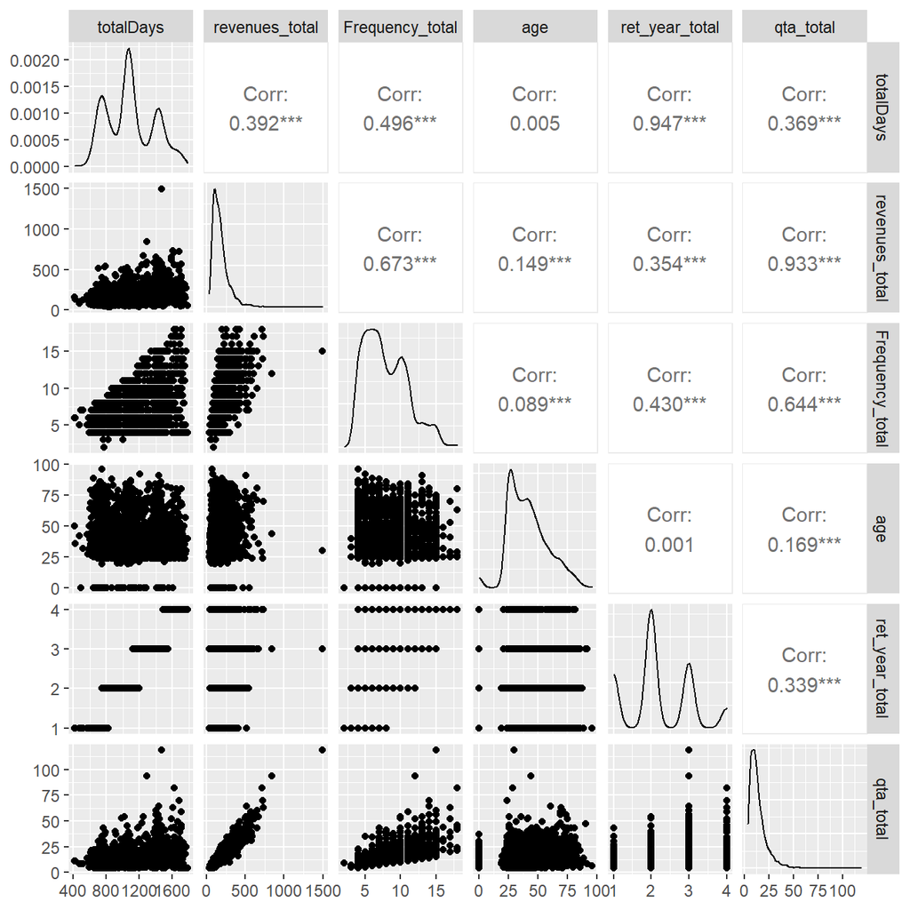

```r
#Convert date to integer
df_assigment_1_notActive$totalDays <- as.numeric(as.character(df_assigment_1_notActive$totalDays))

df_assigment_1_notActive %>%
  select(totalDays, revenues_total, Frequency_total, age, ret_year_total, qta_total) %>%
  ggpairs(alpha = 0.3)
```

## 1.4 Active Customer

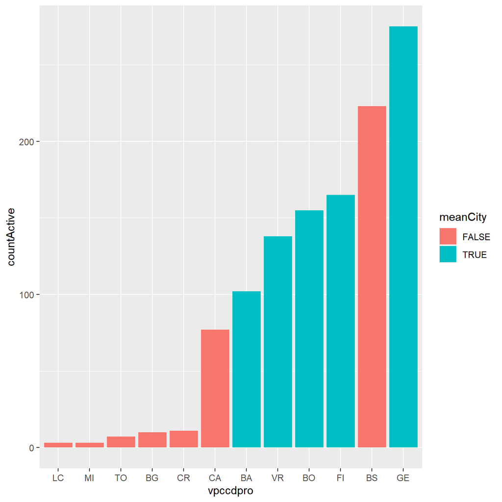

```r
mean_city <- df_assigment_1 %>%
  filter(mean_city == 1) %>%
  select(vpccdpro) %>%
  pull()


df_assigment_1_Active %>%
  group_by(vpccdpro) %>%
  summarise(countActive = count(vpccdpro)) %>%
  mutate(meanCity = vpccdpro%in%mean_city) %>%
  mutate(vpccdpro = fct_reorder(vpccdpro, countActive)) %>%
  ggplot(aes(x=vpccdpro,y=countActive,fill=meanCity)) +
  geom_col()
```